# Random Sampling Techniques

Computer Applications for the Psychological Sciences

2025-11-06

# Parametric Statistics (The General Linear Model)

- When we run summary(lm_model), we are implicitly trusting that our data meets the model assumptions.
- If it doesn’t
  - p-values and confidence intervals can be misleading or just plain wrong.
- Assumptions about the error in GLM (the $\epsilon$ error term):
  - **Normality:** The residuals are assumed to be drawn from a normal (Gaussian) distribution.
  - **Homogeneity of Variance (Homoscedasticity):** The variance of the residuals is assumed to be equal at all levels of the predictor variable.
  - **Independence:** The residuals are assumed to be independent of one another. The error for one data point tells you nothing about the error for another.

# Non-parametric Statistics (computational statistics)

- No traditional assumptions
- Computationally-intensive methods for generating confidence intervals and p-values.
- The “holy trinity” of computational statistics.
  - Bootstrap (Inference) answers: “How uncertain is my statistic?” (Gives CIs)
  - Permutation (Inference) answers: “How likely is my result by chance?” (Gives p-values)
  - Cross-Validation (Prediction) answers: “How well will my model work on new data?” (Gives a model generalization error)

# What if our data and fitted errors looked like this…

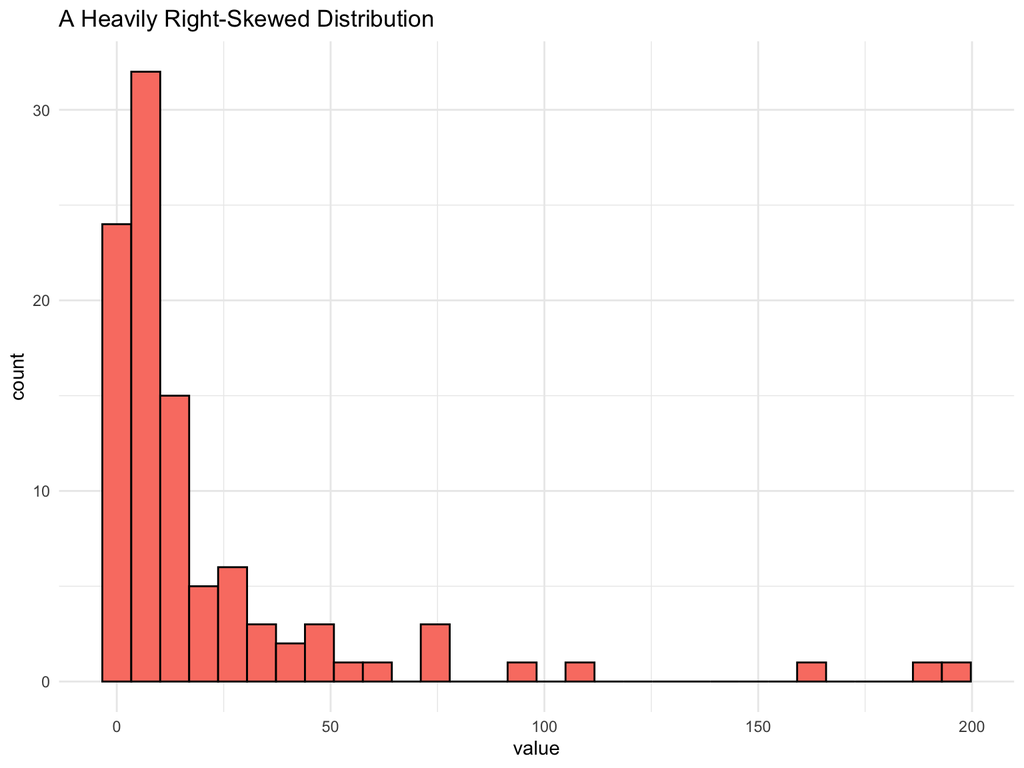

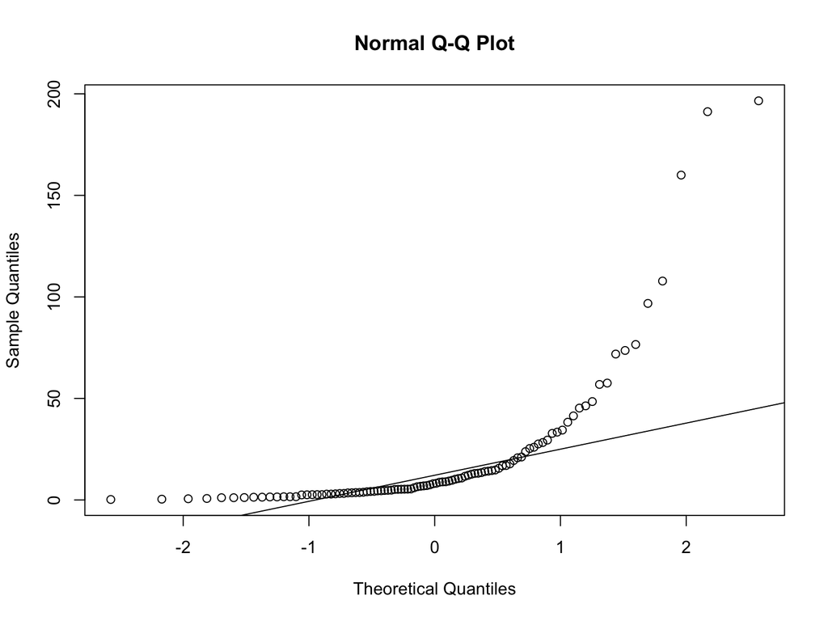

# No Formula Problem

- We have formulas for the CI of a mean (thanks to the Central Limit Theorem), that is actually pretty robust to violations of data shape (e.g., normality).
- But what about a CI for a…
  - Median?
  - R-squared?
  - 90th percentile?
  - parameter estimate in complex models?
- For these, there’s no simple “textbook” formula. We need a new method.

# The Solution: Computational Statistics

- **The Big Idea:**
  - Instead of relying on formulas (which require assumptions), we rely on computation.
- **The Principle:**
  - Our one sample is our best estimate of the true population.
- **The Method:**
  - We can use this one sample to simulate the process of sampling from the population thousands of times.
- This is the core idea of resampling.

# The “Engine” of Resampling: sample()

- This one function drives methods we will cover.
- *Method #1*
  - The Bootstrap (sampling *with* replacement): Simulates drawing new samples from the population.
  - Used for Confidence Intervals.

```r
original_sample <- c(10, 20, 30, 40, 50)
# A "new" sample, with duplicates and omissions
set.seed(123)
sample(original_sample, size = 5, replace = TRUE)
```

```
## [1] 30 30 20 20 30
```

# Bootstrapping for CIs

- Goal: To build a sampling distribution for any statistic.
- The Algorithm:
  - START with your original sample (size n).
  - INITIALIZE an empty vector for results.
  - LOOP 10,000 times:
    - 1. Draw a “bootstrap sample” (size n, replace = TRUE).
    - 2. Calculate your statistic (e.g., median()) on this sample.
    - 3. STORE the statistic in your results vector.
  - FINISH: You now have 10,000 bootstrapped statistics.

# Bootstrapping: From Distribution to CI

- The 10,000 results are the sampling distribution.
- To get a 95% CI, just find the 2.5th and 97.5th percentiles.

```r
set.seed(456)
n_small <- 8
our_data <- rlnorm(n_small, meanlog = 2.0, sdlog = 1)
n_boot <- 10000
boot_medians <- numeric(n_boot)
set.seed(123)
for (i in 1:n_boot) {
  boot_sample <- sample(our_data, size = n_small, replace = TRUE)
  boot_medians[i] <- median(boot_sample)
}

# We'll put our results in a data frame for plotting with ggplot
boot_results_df <- data.frame(medians = boot_medians)

# Get the 95% CI
boot_ci <- quantile(boot_medians, probs = c(0.025, 0.975))
print(boot_ci)
```

```
##      2.5%     97.5%
##  1.927991 14.741151
```

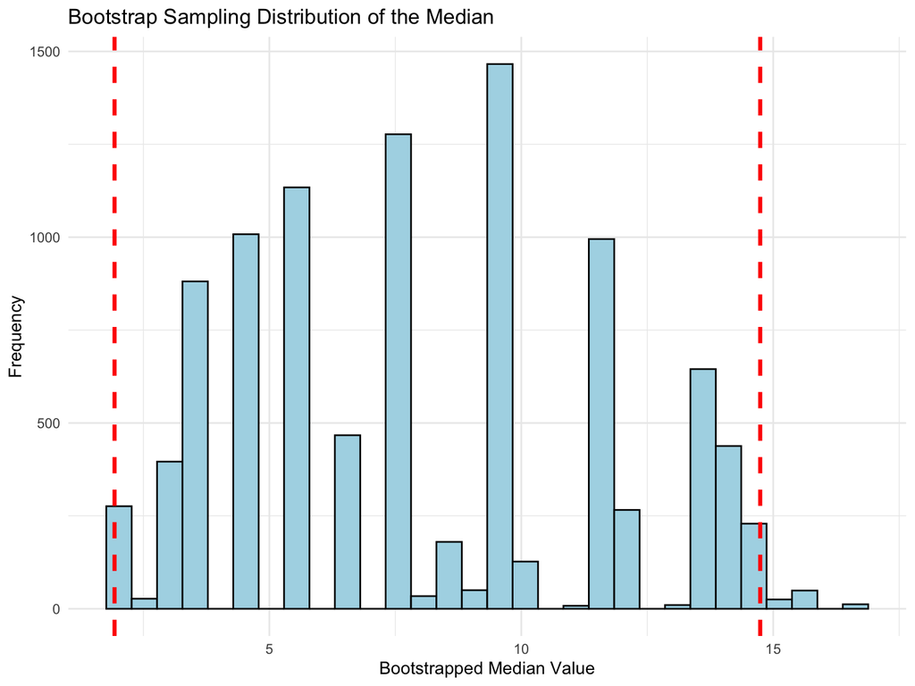

```r
ggplot(boot_results_df, aes(x = medians)) +
  geom_histogram(bins = 30, fill = "lightblue", color = "black") +
  geom_vline(xintercept = boot_ci[1], color = "red", linewidth = 1.2, linetype = "dashed") +
  geom_vline(xintercept = boot_ci[2], color = "red", linewidth = 1.2, linetype = "dashed") +
  theme_minimal() +
  labs(
    title = "Bootstrap Sampling Distribution of the Median",
    x = "Bootstrapped Median Value",
    y = "Frequency"
  )
```

-Key Takeaway: This works for the mean, median, R-squared… anything!

# Permutation Tests for p-values

- Goal: To simulate a “null hypothesis” world where the labels (e.g., “Group A”, “Group B”) are meaningless.
- The Algorithm (for a t-test):
  - START with your two groups.
  - CALCULATE your observed statistic (e.g., mean(A) - mean(B)).
  - INITIALIZE an empty vector for “null” results.
  - LOOP 10,000 times:
    - 1. POOL all outcomes into one big vector.
    - 2. SHUFFLE (permute) the “A” and “B” labels.
    - 3. Calculate the statistic (e.g., mean(fake_A) - mean(fake_B)).
    - 4. STORE this “null” statistic.
  - FINISH: You now have a 10,000-value null distribution.

# Permutation: From Null Distribution to p-value

- The p-value is the proportion of “null” stats that are at least as extreme as your one observed stat.

```r
data("ToothGrowth")
group_a <- ToothGrowth$len[ToothGrowth$supp == "OJ"]
group_b <- ToothGrowth$len[ToothGrowth$supp == "VC"]
observed_diff <- mean(group_a) - mean(group_b)
n_perm <- 10000
null_diffs <- numeric(n_perm)
all_outcomes <- c(group_a, group_b)
all_labels   <- ToothGrowth$supp
set.seed(123)
for (i in 1:n_perm) {
  shuffled_labels <- sample(all_labels, replace=FALSE)
  fake_mean_a <- mean(all_outcomes[shuffled_labels == "OJ"])
  fake_mean_b <- mean(all_outcomes[shuffled_labels == "VC"])
  null_diffs[i] <- fake_mean_a - fake_mean_b
}

# Get the two-tailed p-value
p_value <- sum(abs(null_diffs)>abs(observed_diff))/n_perm
# OR
p_value <- mean(abs(null_diffs) >= abs(observed_diff))
print(paste("Permutation p-value:", p_value))
```

```
## [1] "Permutation p-value: 0.0587"
```

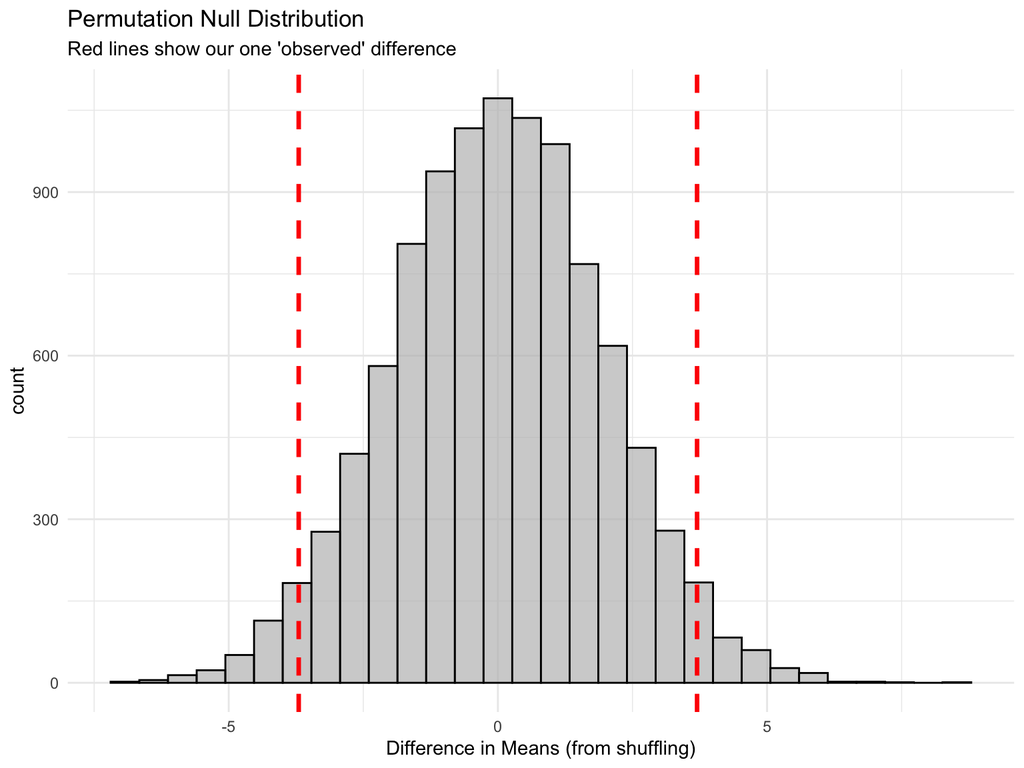

```r
# Let's plot the null distribution and our observed value
null_dist_df <- data.frame(differences = null_diffs)
ggplot(null_dist_df, aes(x = differences)) +
  geom_histogram(bins = 30, fill = "gray", color = "black", alpha = 0.7) +
  geom_vline(xintercept = observed_diff, color = "red", linewidth = 1.2, linetype = "dashed") +
  geom_vline(xintercept = -observed_diff, color = "red", linewidth = 1.2, linetype = "dashed") +
  labs(title = "Permutation Null Distribution",
       subtitle = "Red lines show our one 'observed' difference",
       x = "Difference in Means (from shuffling)") +
  theme_minimal()
```

- For lm(): You can test lm(y ~ x) by shuffling the y vector 10,000 times and storing the slope from lm(shuffled_y ~ x).

# Cross-Validation

- “Why”: $R^2$ from summary(lm()) is “overly optimistic.”
- It’s based on the same data the model was built on.
- This is overfitting.
- The Real Question: How will my model perform on new, unseen data?
- The Method: k-Fold Cross-Validation
  - Split your data into 10 equal “folds” (slices).
  - LOOP 10 times:
    - 1. Hold out Fold 1 as the “test set.”
    - 2. TRAIN the model on the other 9 folds.
    - 3. TEST the model on Fold 1 and store the $R^2$.
    - Repeat, holding out Fold 2, then Fold 3, etc.
  - FINISH: Average your 10 $R^2$ values. This is your “honest” $R^2$.

# Cross-Validation: The Code

```r
data(cars)
set.seed(123)
# 5-fold Cross-validation
cars_folded <- cars %>%
  mutate(fold = sample(1:5, size = nrow(cars), replace = TRUE))

fold_r2s <- numeric(5) # Initialize

for (i in 1:5) {
  test_data  <- cars_folded %>% filter(fold == i)
  train_data <- cars_folded %>% filter(fold != i)

  model <- lm(dist ~ speed, data = train_data)
  predictions <- predict(model, newdata = test_data)

  ss_total <- sum((test_data$dist - mean(test_data$dist))^2)
  ss_resid <- sum((test_data$dist - predictions)^2)
  fold_r2s[i] <- 1 - (ss_resid / ss_total)
}

# Finish
print(round(fold_r2s,3))
```

```
## [1] 0.594 0.278 0.624 0.577 0.651
```

```r
print(paste("Average Cross-Validated R-squared:", round(mean(fold_r2s), 3)))
```

```
## [1] "Average Cross-Validated R-squared: 0.545"
```

```r
optimistic_r2 <- summary(lm(dist ~ speed, data = cars))$r.squared
print(paste("Optimistic R-squared from full dataset:", round(optimistic_r2, 3)))
```

```
## [1] "Optimistic R-squared from full dataset: 0.651"
```